# Counting prediction accuracies PA and ABU

## 1.3 Presence/absence aineisto

### 1.3.1 Aineisto sisälle ja tarkastelu

```r
#model 1: data until 1999; model 2: full data
#mpred1: posterior mean based on model 1; mpred2: posterior mean based on model 2

samples = 1000
thin = 1000  #muista vaihtaa tämä!!
nChains = 4
modeltype = 1 #1 on pa-aineistolle

filename = file.path(PredictionDir, paste("predictions_",c("pa","abundance")[modeltype],
                                          "_chains_",as.character(nChains),"_thin_", as.character(thin),"_samples_", as.character(samples),
                                          ".Rdata",sep = ""))
load(filename) #mpred1, mpred2, Y, studyDesign

routes=levels(studyDesign$Route)
nr=length(routes)
years=levels(studyDesign$Year)
ns=dim(mpred1)[2]
```

### 1.3.2 Periodien määrittely

Päädyttiiin valitsemaan aikaisempi ajankohta periodi 1:lle. Näin ennusteet tehdään pidemmälle aikavälille ja ehkä muutoksetkin ovat silloin isompia ja helpommin ennustettavia. Alunperin ajankohta oli 2003-2006 koska silloin aineistoa oli enemmän ja laadukkaammin saatavilla.

```r
period1=(studyDesign$Year=="Year_1996" | studyDesign$Year=="Year_1997" | studyDesign$Year=="Year_1998" | studyDesign$Year=="Year_1999")
period2=(studyDesign$Year=="Year_2013" | studyDesign$Year=="Year_2014" | studyDesign$Year=="Year_2015" | studyDesign$Year=="Year_2016")

pm1p1=mpred1[period1,]
pm2p1=mpred2[period1,]

pm1p2=mpred1[period2,] #pm1p2 = predictions by model 1 to period 2
pm2p2=mpred2[period2,]

y1=Y[period1,]
y2=Y[period2,]

sd1 = studyDesign[period1,]
sd2 = studyDesign[period2,]

visits1 = rep(NA,nr)
visits2 = rep(NA,nr)
for (i in 1:nr){
  visits1[i] = sum(sd1$Route==routes[i])
  visits2[i] = sum(sd2$Route==routes[i])
}
```

### 1.3.3 Ennustustarkkuudet metodeilla A ja B

Lasketaan ennustustarkkuus kun ennustetaan kunkin lajin esiintymistodennäköisyyttä yhtenä ajanhetkenä (periodi 2).  
A: Mallin kalibrointiin on käytetty aineistoa samalta ajalta.  
B: Mallin kalibrointiin EI ole käytetty aineistoa samalta ajalta.

```r
# COMPUTE MEASURES A AND B
selroutes = routes[which(visits2>=2)]  #periodi 2, joten vesilintujen NA:t eivät vaikuta näissä laskuissa
nsr = length(selroutes)

Ap1=matrix(NA,nrow = nsr,ncol = ns)
Ap2=matrix(NA,nrow = nsr,ncol = ns)
Ay=matrix(NA,nrow = nsr,ncol = ns)
for (i in 1:nsr){
  take = which(sd2$Route == selroutes[i])
  Ap1[i,] = colMeans(pm1p2[take,])
  Ap2[i,] = colMeans(pm2p2[take,])
  Ay[i,] = colMeans(y2[take,])
}
A = rep(NA,ns)
B = rep(NA,ns)
for (i in 1:ns){
  A[i] = cor(Ap2[,i],Ay[,i])
  B[i] = cor(Ap1[,i],Ay[,i])
}

nsr
```

```
## [1] 1214
```

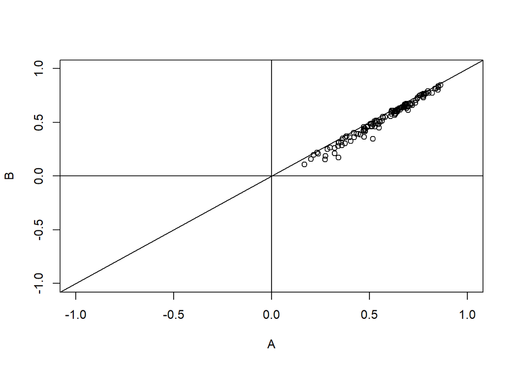

```
## integer(0)
```

```r
plot(A,B,xlim=c(-1,1), ylim=c(-1,1)) + abline(0,1)+ abline(h=0)+ abline(v=0)
```

Molemmat metodit ennustavat hyvin. A:lle ennusteet (eli interpoloidessa) ovat vähän parempia kuin B:lle.

### 1.3.4 Ennustustarkkuudet metodeilla C ja D

Lasketaan ennustustarkkuus kun ennustetaan kunkin lajin esiintymistodennäköisyyden muutosta periodien 1 ja 2 välillä.  
C: Mallin kalibrointiin on käytetty aineistoa samalta ajalta.  
D: Mallin kalibrointiin EI ole käytetty aineistoa samalta ajalta (periodin 2 osalta).

```r
# COMPUTE MEASURES C AND D
selroutes = routes[which(visits1>=2 & visits2>=2)]
nsr = length(selroutes)

Ap1=matrix(NA,nrow = nsr,ncol = ns)
Ap2=matrix(NA,nrow = nsr,ncol = ns)
Ay=matrix(NA,nrow = nsr,ncol = ns)
for (i in 1:nsr){
  take1 = which(sd1$Route == selroutes[i])
  take2 = which(sd2$Route == selroutes[i])
  Ap1[i,] = colMeans(pm1p2[take2,])-colMeans(pm1p1[take1,]) #ennusteisiin ei tule NA:ta mutta seuraavissa laskuissa havaintojen NA eliminoi tämän ongelman
  Ap2[i,] = colMeans(pm2p2[take2,])-colMeans(pm2p1[take1,])
  Ay[i,] = colMeans(y2[take2,])- colMeans(y1[take1,])   #Suomen vesilintujen NA:t säilyvät
}
C = rep(NA,ns)
D = rep(NA,ns)
for (i in 1:ns){
  C[i] = cor(Ap2[,i],Ay[,i], use="na.or.complete")  #NA:t eivät estä korrelaation laskemista koko lajille
  D[i] = cor(Ap1[,i],Ay[,i], use="na.or.complete")
}
nsr
```

```
## [1] 264
```

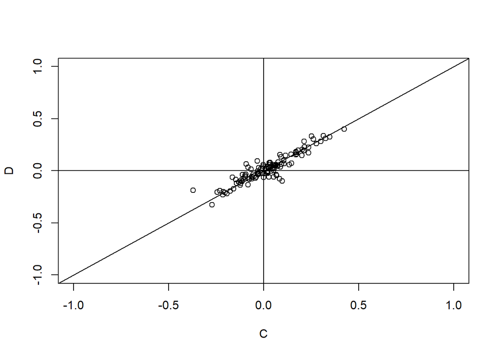

```
## integer(0)
```

```r
plot(C,D,xlim=c(-1,1), ylim=c(-1,1)) + abline(0,1)+ abline(h=0)+ abline(v=0)
```

Molemmille metodeille ennusteet aika huonoja.

**HUOM!** Presence/absence aineistossa mm. Suomen vesilinnut ovat NA:ta ennen vuotta 2006. Periodi 1:sen kaikki arvot vesilinnuille Suomessa ovat siis NA, eivätkä tule mukaan laskelmiin. Korrelaatiota laskiessa argumentti “use=”na.or.complete“” varmistaa, että korrelaatio lasketaan muista kuin NA-arvoista.

### 1.3.5 Muutama esimerkkilaji

Plottaan parille lajille ennustetut (D) ja todelliset muutokset reiteittäin. Yksi piste on siis yksi reitti.

```r
pred=Ap1[,21]
obs=Ay[,21]
laji=as.data.frame(cbind(pred,obs))
#tarkistus
cor(pred,obs, use="na.or.complete")
```

```
## [1] -0.1214087
```

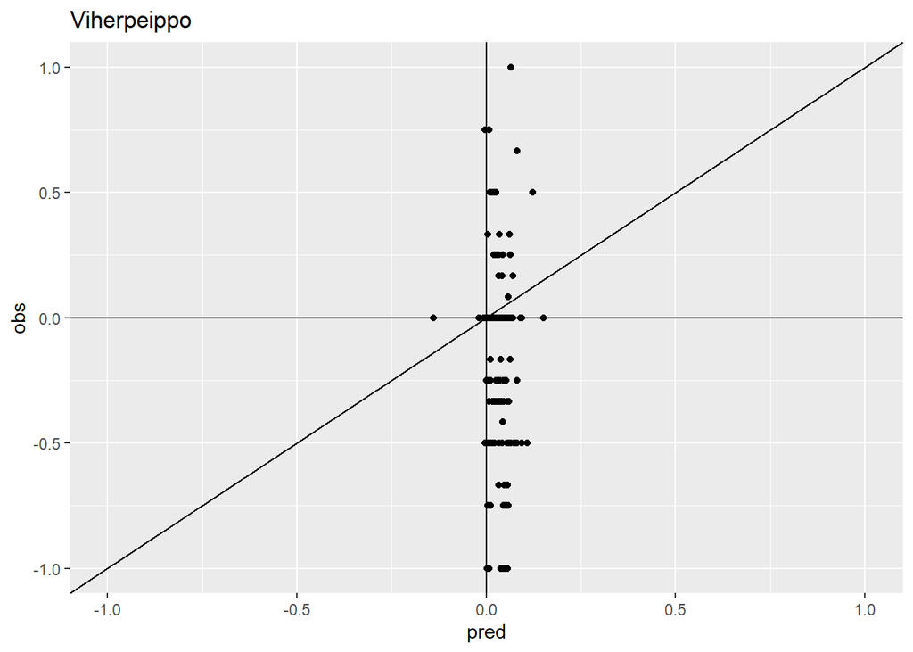

```r
#kuvaaja
ggplot(laji, aes(x=pred,y=obs))+ geom_point()+ xlim(-1,1)+ylim(-1,1)+ geom_abline(intercept = 0, slope =1) + geom_hline(yintercept=0) + geom_vline(xintercept = 0) +ggtitle("Viherpeippo")
```

```r
#entäpä tikli?
pred=Ap1[,20]
obs=Ay[,20]
laji=as.data.frame(cbind(pred,obs))
#tarkistus
cor(pred,obs, use="na.or.complete")
```

```
## [1] 0.401333
```

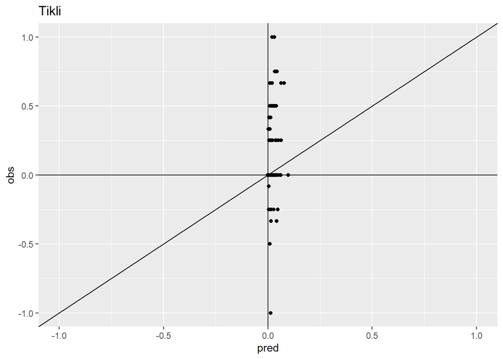

```r
#kuvaaja
ggplot(laji, aes(x=pred,y=obs))+ geom_point()+ xlim(-1,1)+ylim(-1,1)+ geom_abline(intercept = 0, slope =1) + geom_hline(yintercept=0) + geom_vline(xintercept = 0) +ggtitle("Tikli")
```

Yhtä lajia tarkastellessa huomaa miten pa-aineistolla ennusteet ovat lähellä nollaa mutta havainnot vaihtelevat “rajummin” -1 ja 1 välillä. Ennusteet ovat positiivisia mutta havainnot taitavat olla suuremmaksi osaksi nollaa tai negatiivisia. Viherpeipon ennustustarkkuus olikin pa-aineistolle -0.12. Tiklille tarkkuus oli parempi 0.40.

Tarkistan vielä kuinka monesta havaintoparista kunkin lajin korrelaatio on laskettu. Pa-aineistolla joukosta puuttuvat vain muutamat vesilintujen NA-havainnot. Abu-aineistolla tilanne on eri.

```r
P_D = rep(NA,ns)
for (i in 1:ns){
  P_D[i] = pairwiseCount(Ap1[,i],Ay[,i])
}
sort(P_D)
```

```
##   [1] 261 261 261 261 261 261 261 261 261 261 261 261 261 261 261 261 261
##  [18] 261 261 264 264 264 264 264 264 264 264 264 264 264 264 264 264 264
##  [35] 264 264 264 264 264 264 264 264 264 264 264 264 264 264 264 264 264
##  [52] 264 264 264 264 264 264 264 264 264 264 264 264 264 264 264 264 264
##  [69] 264 264 264 264 264 264 264 264 264 264 264 264 264 264 264 264 264
##  [86] 264 264 264 264 264 264 264 264 264 264 264 264 264 264 264 264 264
## [103] 264 264 264 264 264 264 264 264 264 264 264 264 264 264 264 264 264
## [120] 264
```

Korrelaatiot on laskettu useiden reittiparien avulla pa-aineistossa. Hyvä niin.

### 1.3.6 Tulokset

Pa-aineiston kunkin metodin ennustustarkkuuksien keskiarvot:

```r
#create a table
meres=c(mean(A,na.rm = TRUE),mean(B,na.rm = TRUE),mean(C,na.rm = TRUE),mean(D,na.rm = TRUE))
names(meres)=c("A","B","C","D")
meres
```

```
##          A          B          C          D
## 0.57490475 0.53554029 0.02324779 0.02386376
```

```r
#write.csv(meres,file="pa_species_specific_route_level.csv")
```

Keskiarvot näyttävät suht surkeilta tyyleille C ja D. Eli nimenomaan muutoksen ennustaminen on vaikeaa. Vaikka mallin kalibrointiin olisi käytetty aineistoa samalta ajalta kuin mihin yritetään ennustaa (C).

```r
#save results as datatable for further analysis
species=colnames(Y)
pa_results=data.frame(species,A,B,C,D)
setnames(pa_results,c("A","B","C","D"),c("pa_A","pa_B","pa_C","pa_D"))
write.csv(pa_results, "pa_results.csv",row.names = F)
pa_results
```

```
##                           species      pa_A      pa_B          pa_C
## 1          Acrocephalus_palustris 0.6204594 0.6085482  0.2777913446
## 2      Acrocephalus_schoenobaenus 0.3773600 0.3616274  0.0547413876
## 3         Acrocephalus_scirpaceus 0.5141255 0.4649177 -0.1762913472
## 4              Actitis_hypoleucos 0.1672405 0.1095757  0.0842395840
## 5             Aegithalos_caudatus 0.3636997 0.3504001 -0.0384437581
## 6                 Alauda_arvensis 0.7994701 0.7917381 -0.1235922667
## 7                     Anas_crecca 0.2015863 0.1585892 -0.1069590955
## 8              Anas_platyrhynchos 0.6138883 0.5791470 -0.0603299884
## 9                     Anser_anser 0.5556853 0.5032241  0.3484426022
## 10               Anthus_pratensis 0.7338227 0.6822328  0.0751438559
## 11               Anthus_trivialis 0.6996384 0.6475016 -0.0914388388
## 12                      Apus_apus 0.6668890 0.6402201  0.0139844381
## 13                  Ardea_cinerea 0.5046091 0.4842252 -0.0973993873
## 14                Aythya_fuligula 0.2847223 0.2497333 -0.0142420607
```

[output cut: 227 more lines]

### 1.3.7 Todelliset ja ennustetut muutokset tutkimusalueella

Tarkastellaan absoluuttisia todellisia ja ennustettuja muutoksia esiintymistodennäköisyyksissä koko tutkimusalueella. Ennusteet on tehty joko tyyliin C tai D, eli koko aineistoa tai osittaista aineistoa hyödyntämällä. Paperiin voisi tarvittaessa varmaan valita vain metodin D.

```r
#kannanmuutostrendien tarkastelu, lasketaan kaikilta linjoilta ennustetut ja todelliset kannanmuutokset
Ap1<-as.data.frame(Ap1)
Ap2<-as.data.frame(Ap2)
Ay<-as.data.frame(Ay)

#aineisto, jossa kullekin lajille laskettu kaikilta linjoilta ennustettu ja todellinen muutoksen keskiarvo (EI siis korrelaatio
# ennusteiden ja oikeiden muutosten välillä kuten aiemmin on laskettu vaan vähän niinkuin olisi poolattu koko aineisto yhteen lukemaan)
kat=colnames(Y)
kat=as.data.frame(kat)
kat$Ap1k=colMeans(Ap1,na.rm = T)
kat$Ap2k<-colMeans(Ap2,na.rm = T)
kat$Ayk<-colMeans(Ay,na.rm = T)
```

Ensin tyyliin C, eli käyttäen koko aineistoa vuoteen 2016.

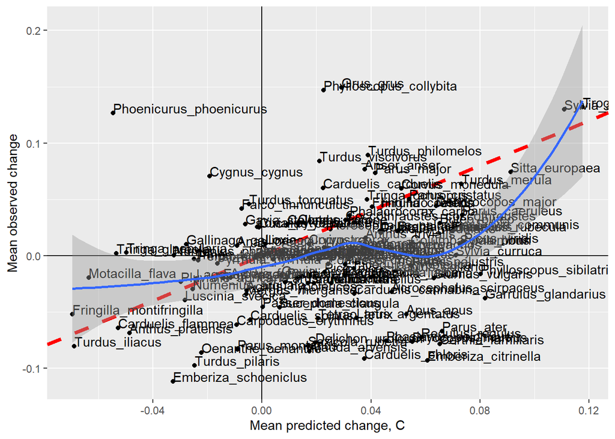

```r
ggplot(kat, aes(x=Ap2k, y=Ayk))+ geom_point()+
  geom_hline(yintercept = 0, color = "black")+
  geom_vline(xintercept = 0, color = "black")+
  xlab("Mean predicted change, C")+
  ylab("Mean observed change")+
  geom_abline(intercept = 0, slope = 1, color="red",linetype="dashed", size=1.5)+
  geom_text(aes(label=kat),hjust=0, vjust=0) + geom_smooth()
```

Kuvassa yksi piste on yksi laji. X-akselilla on lajin ennustetun esiintymistod.näk. muutos. Y-akselilla todellinen muutos. Nämä on laskettu tutkimusalueen jokaisen reitin (missä lajia on havaittu) keskiarvona. Punainen katkoviiva merkkaa täydellista vastaavuutta. Mitä lähempänä viivaa havainto on, sitä paremmin ennuste on mennyt nappiin. Sininen viiva on aineiston regressiokäyrä.

Tyyli D, eli käyttäen aineistoa vuoteen 1999:

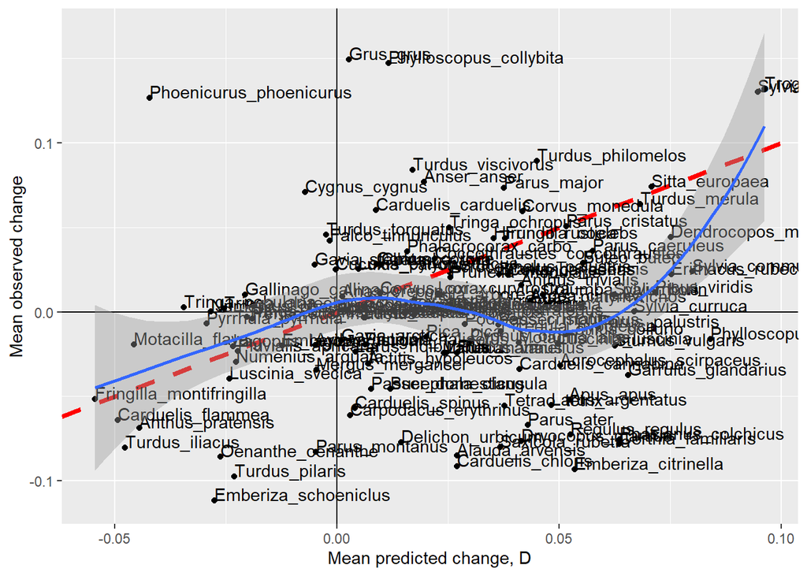

```r
ggplot(kat, aes(x=Ap1k, y=Ayk))+
  geom_point()+ geom_hline(yintercept = 0, color = "black")+
  geom_vline(xintercept = 0, color = "black")+
  xlab("Mean predicted change, D")+
  ylab("Mean observed change")+
  geom_abline(intercept = 0, slope = 1, color="red",linetype="dashed", size=1.5)+
  geom_text(aes(label=kat),hjust=0, vjust=0)+  geom_smooth()
```

```r
#tallennetaan tarvittaessa
write.csv(kat,"mean_observed_predicted_changes_pa.csv",row.names = F)
```

Huomaa kuvissa hieman eri skaala. Kun mallintamisessa käytetään vähemmän aineistoa (-1999) ennustetut muutokset ovat joillekin lajeille (yläkulman Sylvia) hieman pienempiä.

#### tapahtuneen muutoksen ja ennustustarkkuuden suhde

Kuvaaja muutoksen suuruuden ja ennustustarkkuuden suhteesta:

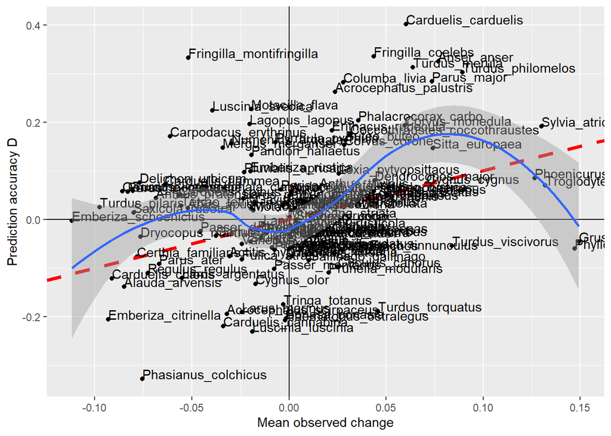

```r
kat2=cbind(kat,pa_results)

ggplot(kat2, aes(x=Ayk, y=pa_D))+
  geom_point()+ geom_hline(yintercept = 0, color = "black")+
  geom_vline(xintercept = 0, color = "black")+
  xlab("Mean observed change")+
  ylab("Prediction accuracy D")+
  geom_abline(intercept = 0, slope = 1, color="red",linetype="dashed", size=1.5)+
  geom_text(aes(label=kat),hjust=0, vjust=0)+  geom_smooth()
```

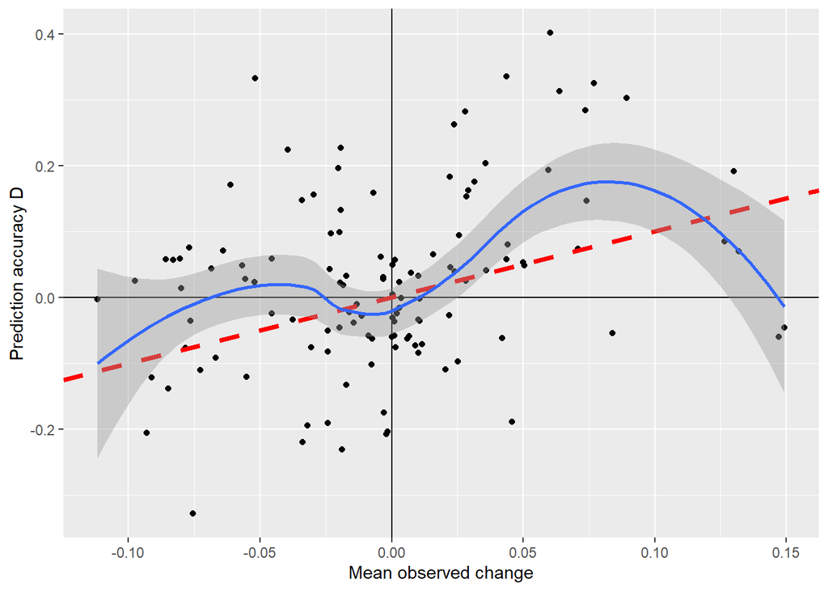

```r
ggplot(kat2, aes(x=Ayk, y=pa_D))+
  geom_point()+ geom_hline(yintercept = 0, color = "black")+
  geom_vline(xintercept = 0, color = "black")+
  xlab("Mean observed change")+
  ylab("Prediction accuracy D")+
  geom_abline(intercept = 0, slope = 1, color="red",linetype="dashed", size=1.5)+  geom_smooth()
```

Eli tästä pitäisi voida päätellä, että jos muutosta on tapahtunut, suuntaan tai toiseen, runsastumista ja vähentymistä, ennustustarkkuus pitäisi olla suurempi, kuin jos lajin esiintymisessä ei ole tapahtunut mitään muutosta, jolloin on vaikeampi mallintaa taikka ennustaakaan mitään. Smootherin pitäisi olla lavean U:n muotoinen paraabeli, jonka pohja on origossa tai sen alapuolella?

Näistä kuvaajista on ehkäpä vaikea saada paljoa irti koska ennustustarkkuudet ovat niin huonoja yleisesti. Ehkä myös siksi, että muutos on laskettu koko alueelle. Eli vähentyminen toisaalla ja runsastuminen toisaalla saattavat kumota toisensa.

Lasken varianssin muutoksista jokaisella 264 linjalla, jota ennustustarkkuuden laskemiseen on käytetty.

```r
dat=as.data.frame(t(Ay))
dat$row_var=rowVars(as.matrix(dat),na.rm = TRUE)
dat=cbind(dat,pa_results)
```

Ja plottaan tulokset:

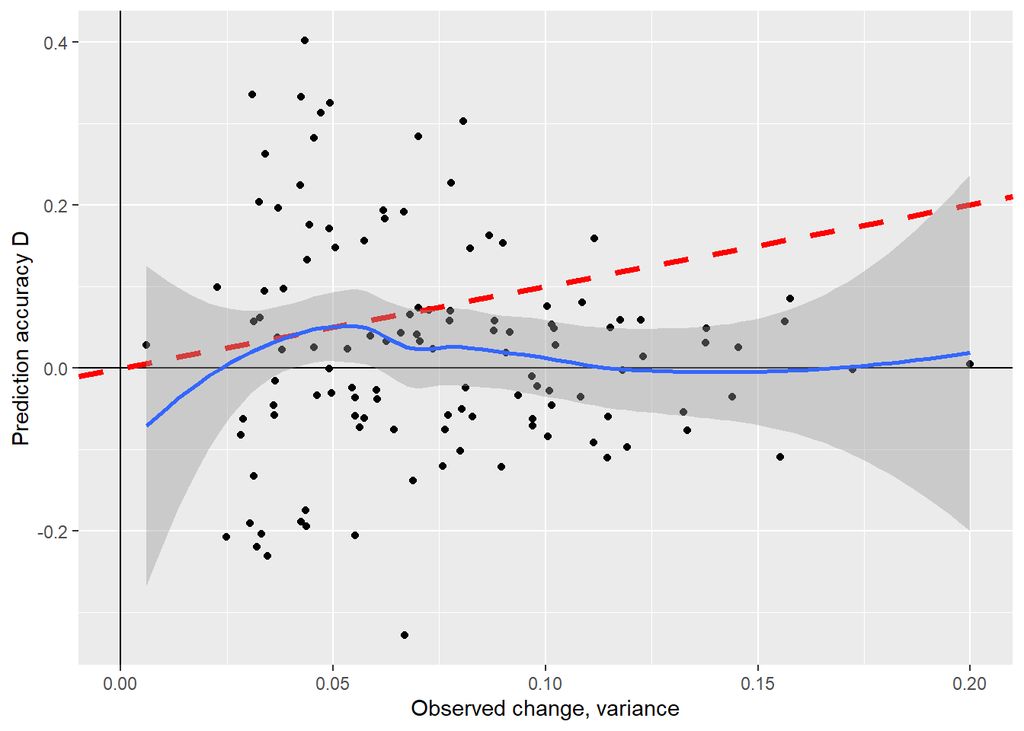

```r
ggplot(dat, aes(x=row_var, y=pa_D))+
  geom_point()+ geom_hline(yintercept = 0, color = "black")+
  geom_vline(xintercept = 0, color = "black")+
  xlab("Observed change, variance")+
  ylab("Prediction accuracy D")+
  geom_abline(intercept = 0, slope = 1, color="red",linetype="dashed", size=1.5)+  geom_smooth()
```

Ei varsinaista selvää suhdetta muutoksen varianssin ja ennustustarkkuuden välillä. Ennemminkin paljon lajeja, joilla on pieniä muutoksia, mutta ennustustarkkuus voi olla mitä tahansa, suht hyväkin vaikka muutokset eivät olisikaan olleet suuria.

Onko tuo varianssi paras tapa mitata sitä, onko muutosta tapahtunut paljon vai vähän? On kai.

## 1.4 Abundance-aineisto

Lasketaan kaikki samat asiat abundance-aineistolla.

```r
modeltype = 2 #2 on abu-aineistolle

filename = file.path(PredictionDir, paste("predictions_",c("pa","abundance")[modeltype],                                    "_chains_",as.character(nChains),"_thin_", as.character(thin),"_samples_", as.character(samples),".Rdata",sep = ""))

load(filename) #mpred1, mpred2, Y, studyDesign
routes=levels(studyDesign$Route)
nr=length(routes)
years=levels(studyDesign$Year)
ns=dim(mpred1)[2]
```

### 1.4.1 Periodien määrittely

```r
pm1p1=mpred1[period1,]
pm2p1=mpred2[period1,]

pm1p2=mpred1[period2,] #pm1p2 = predictions by model 1 to period 2
pm2p2=mpred2[period2,]

y1=Y[period1,]
y2=Y[period2,]

sd1 = studyDesign[period1,]
sd2 = studyDesign[period2,]

visits1 = rep(NA,nr)
visits2 = rep(NA,nr)
for (i in 1:nr){
  visits1[i] = sum(sd1$Route==routes[i])
  visits2[i] = sum(sd2$Route==routes[i])
}
```

### 1.4.2 Ennustustarkkuudet A ja B

```r
# COMPUTE MEASURES A AND B
selroutes = routes[which(visits2>=2)]
nsr = length(selroutes)

Ap1=matrix(NA,nrow = nsr,ncol = ns)
Ap2=matrix(NA,nrow = nsr,ncol = ns)
Ay=matrix(NA,nrow = nsr,ncol = ns)

for (j in 1:ns) {
  for (i in 1:nsr){
    take = which(sd2$Route == selroutes[i] & y2[,j]>-1)
    Ap1[i,j] = mean(pm1p2[take,j])
    Ap2[i,j] = mean(pm2p2[take,j])
    Ay[i,j] = mean(y2[take,j],na.rm=T)
  }}

A = rep(NA,ns)
B = rep(NA,ns)
for (i in 1:ns){
  A[i] = cor(Ap2[,i],Ay[,i],use="na.or.complete")   #lisäsin tähän määreen
  B[i] = cor(Ap1[,i],Ay[,i],use="na.or.complete")
}
nsr
```

```
## [1] 1214
```

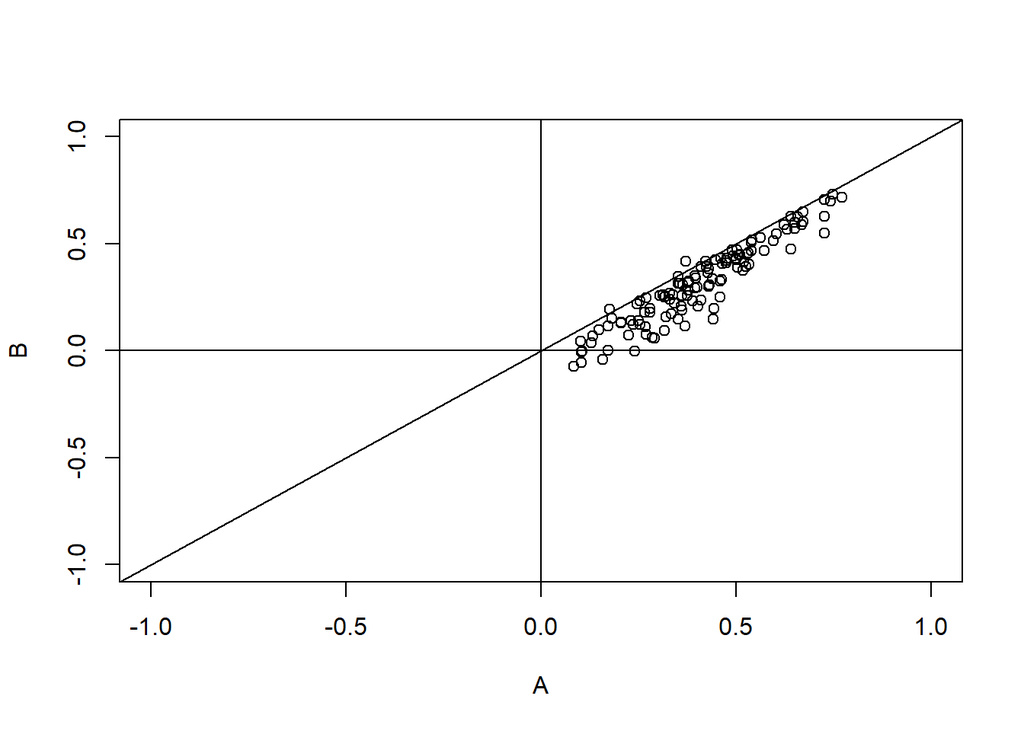

```
## integer(0)
```

```r
plot(A,B,xlim=c(-1,1), ylim=c(-1,1)) + abline(0,1)+ abline(h=0)+ abline(v=0)
```

Molemmat metodit suht hyviä. A:lle ennusteet parempia.

Lasken kuinka monesta havaintoparista ennustustarkkuus kullekin lajille lasketaan.

```r
P_D = rep(NA,ns)
for (i in 1:ns){
  P_D[i] = pairwiseCount(Ap1[,i],Ay[,i])
}
sort(P_D)
```

```
##   [1]   67   74   82   97  101  115  115  118  122  123  123  133  135  136
##  [15]  143  147  159  161  163  167  170  173  173  173  174  174  178  178
##  [29]  180  189  202  204  214  215  217  223  235  236  237  238  277  279
##  [43]  286  288  291  294  305  308  314  320  320  322  333  334  337  340
##  [57]  341  353  356  375  378  394  413  423  443  449  451  452  456  457
##  [71]  462  469  471  473  483  488  502  516  526  536  542  553  569  573
##  [85]  579  592  596  605  610  610  620  636  689  699  704  710  718  721
##  [99]  724  727  735  745  776  791  827  844  861  864  866  874  895  922
## [113]  960  964  994 1002 1026 1056 1082 1182
```

```r
mean(P_D)
```

```
## [1] 442.6833
```

### 1.4.3 Ennustustarkkuudet C ja D

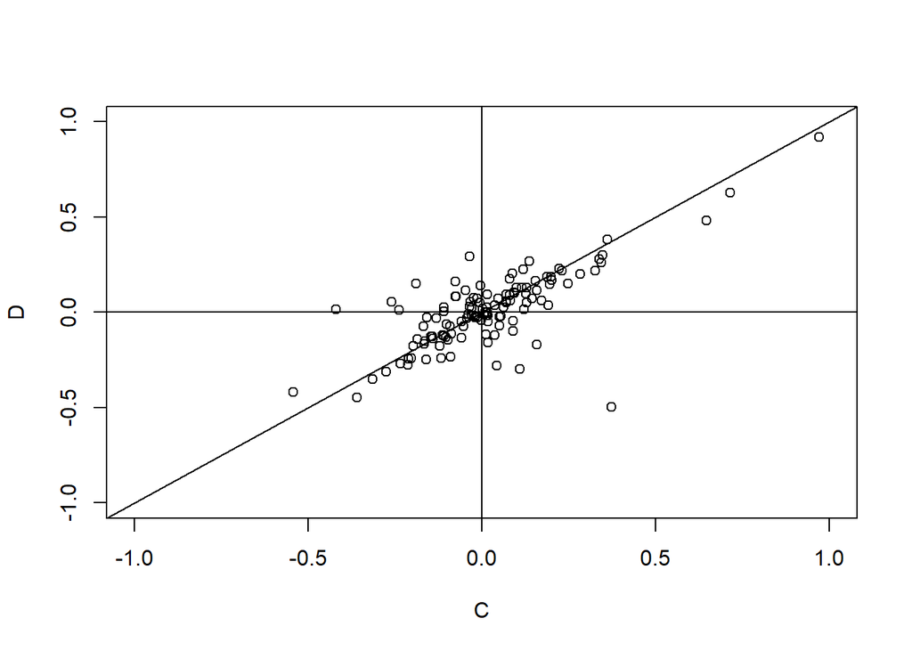

```
## integer(0)
```

```r
# COMPUTE MEASURES C AND D
selroutes = routes[which(visits1>=2 & visits2>=2)]
nsr = length(selroutes)

Ap1=matrix(NA,nrow = nsr,ncol = ns)
Ap2=matrix(NA,nrow = nsr,ncol = ns)
Ay=matrix(NA,nrow = nsr,ncol = ns)

for (j in 1:ns){
  for (i in 1:nsr){
    take1 = which(sd1$Route == selroutes[i] & y1[,j]>-1)
    take2 = which(sd2$Route == selroutes[i]& y2[,j]>-1)
    Ap1[i,j] = mean(pm1p2[take2,j])-mean(pm1p1[take1,j]) #ka laskettava vain vuosilta, jolloin lajia on havaittu
    Ap2[i,j] = mean(pm2p2[take2,j])-mean(pm2p1[take1,j]) #riittää, että on edes kerran pystytty laskemaan lajia
    Ay[i,j] = mean(y2[take2,j],na.rm=T)- mean(y1[take1,j],na.rm=T) #NA:t eivät saa estää keskiarvon laskemista koko lajille.
  }}

C = rep(NA,ns)
D = rep(NA,ns)
for (i in 1:ns){
  C[i] = cor(Ap2[,i],Ay[,i],use="na.or.complete")    #lisäsin tähän määreen
  D[i] = cor(Ap1[,i],Ay[,i],use="na.or.complete")
}
plot(C,D,xlim=c(-1,1), ylim=c(-1,1)) + abline(0,1)+ abline(h=0)+ abline(v=0)
```

Molemmat metodit arvioivat ennusteet suht huonoiksi.

**HUOM!** Abundance aineistolla riittää, että lajia on kunkin periodin aikana havaittu edes kerran. PA-aineistolla havaintoja piti olla vähintään kaksi. Kummallakin aineistolla reitillä pitää olla käyty vähintään kaksi kertaa.

### 1.4.4 Tulokset

Keskiarvot:

```r
meres=c(mean(A,na.rm = TRUE),mean(B,na.rm = TRUE),mean(C,na.rm = TRUE),mean(D,na.rm = TRUE))
names(meres)=c("A","B","C","D")
meres
```

```
##          A          B          C          D
## 0.40547113 0.31279760 0.02019191 0.01062028
```

Myös abu-aineistolla varsinkin muutoksen ennustaminen on vaikeaa.

```r
#save as datatable
species=colnames(Y)
abu_results=data.frame(species,A,B,C,D)
setnames(abu_results,c("A","B","C","D"),c("abu_A","abu_B","abu_C","abu_D"))
write.csv(abu_results, "abu_results.csv",row.names = F)

#combine data frames
res=inner_join(pa_results,abu_results,by="species")

#save as csv for further analysis
write.csv(res,"results.csv",row.names = F)
abu_results
```

```
##                           species      abu_A        abu_B        abu_C
## 1          Acrocephalus_palustris 0.52498746  0.393761959  0.119209288
## 2      Acrocephalus_schoenobaenus 0.23150182  0.138659378  0.248753254
## 3         Acrocephalus_scirpaceus 0.31591033  0.094009432 -0.139603935
## 4              Actitis_hypoleucos 0.29158936  0.059344741 -0.058236777
## 5             Aegithalos_caudatus 0.40159576  0.207514775  0.373024646
## 6                 Alauda_arvensis 0.67174613  0.649974719 -0.035716017
## 7                     Anas_crecca 0.24049479 -0.002813881 -0.089619324
## 8              Anas_platyrhynchos 0.50925821  0.448092978  0.120693277
## 9                     Anser_anser 0.37888745  0.324876985 -0.274689819
## 10               Anthus_pratensis 0.77249150  0.717583082  0.362234861
## 11               Anthus_trivialis 0.62387255  0.587841272 -0.028131814
## 12                      Apus_apus 0.44839621  0.425409405  0.089838066
## 13                  Ardea_cinerea 0.31812563  0.253206673  0.093643884
## 14                Aythya_fuligula 0.39434300  0.294091127 -0.420687149
```

[output cut: 227 more lines]

### 1.4.5 Muutama esimerkkilaji

Plottaan malliksi viherpeipon ja pohjansirkun:

```r
pred=Ap1[,21]
obs=Ay[,21]
laji=as.data.frame(cbind(pred,obs))
#tarkistus
cor(pred,obs, use="na.or.complete")
```

```
## [1] 0.03655918
```

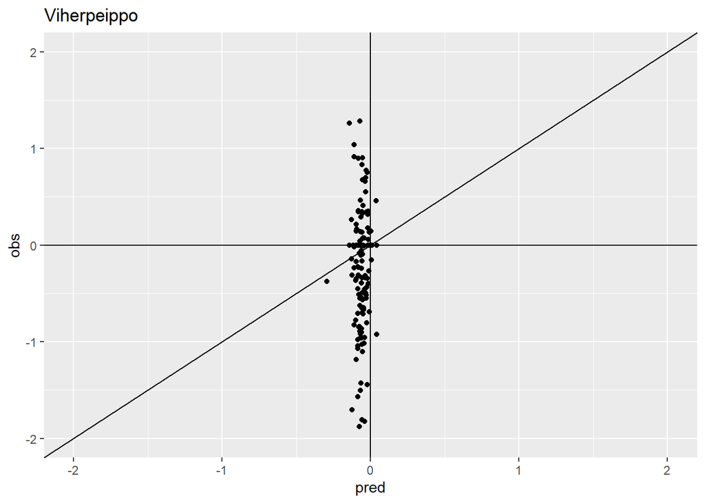

```r
#kuvaaja
ggplot(laji, aes(x=pred,y=obs))+ geom_point()+ xlim(-2,2)+ylim(-2,2)+ geom_abline(intercept = 0, slope =1) + geom_hline(yintercept=0) + geom_vline(xintercept = 0) +ggtitle("Viherpeippo")
```

```r
#entäpä pohjansirkku?
pred=Ap1[,40]
obs=Ay[,40]
laji=as.data.frame(cbind(pred,obs))
#tarkistus
cor(pred,obs, use="na.or.complete")
```

```
## [1] 0.9208667
```

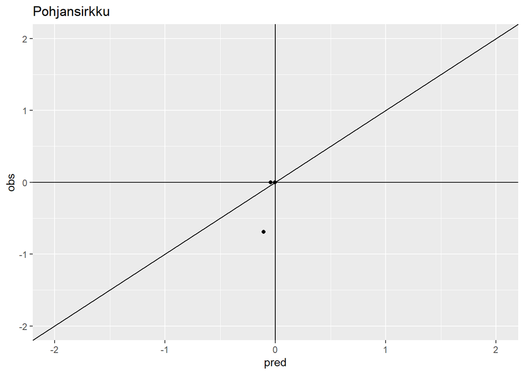

```r
#kuvaaja
ggplot(laji, aes(x=pred,y=obs))+ geom_point()+ xlim(-2,2)+ylim(-2,2)+ geom_abline(intercept = 0, slope =1) + geom_hline(yintercept=0) + geom_vline(xintercept = 0) +ggtitle("Pohjansirkku")
```

```r
P_D = rep(NA,ns)
for (i in 1:ns){
  P_D[i] = pairwiseCount(Ap1[,i],Ay[,i])
}
sort(P_D)
```

```
##   [1]   3   4  10  10  11  12  12  13  14  15  15  16  17  17  19  19  20
##  [18]  21  22  22  23  25  25  27  27  29  29  29  31  32  32  32  32  34
##  [35]  34  35  35  37  37  38  39  42  43  43  43  44  47  47  52  54  58
##  [52]  60  61  61  62  62  63  65  66  72  73  73  75  76  79  81  83  83
##  [69]  84  86  87  87  88  89  91  91  92  92  93 100 104 104 107 108 110
##  [86] 112 112 118 119 119 119 120 127 130 133 135 143 146 147 148 150 151
## [103] 159 159 160 163 164 166 179 182 193 196 196 207 214 218 224 224 231
## [120] 262
```

```r
mean(P_D)
```

```
## [1] 83.00833
```

```r
#liitän uuden sarakkeen tuloksiin
res=cbind(res,P_D)
#save as csv for further analysis
write.csv(res,"results.csv",row.names = F)
```

**Huom!** Muista, että abu-arvot ovat yksilömäärien logaritmeja.

### 1.4.6 Todelliset ja ennustetut muutokset tutkimusalueella

```r
#kannanmuutostrendien tarkastelu, lasketaan kaikilta linjoilta ennustetut ja todelliset kannanmuutokset
Ap1<-as.data.frame(Ap1)
Ap2<-as.data.frame(Ap2)
Ay<-as.data.frame(Ay)

#aineisto, jossa kullekin lajille laskettu kaikilta linjoilta ennustettu ja todellinen muutoksen keskiarvo (EI siis korrelaatio
# ennusteiden ja oikeiden muutosten välillä kuten aiemmin on laskettu)
kat=colnames(Y)
kat=as.data.frame(kat)
kat$Ap1k=colMeans(Ap1,na.rm = T)
kat$Ap2k<-colMeans(Ap2,na.rm = T)
kat$Ayk<-colMeans(Ay,na.rm = T)
```

Tyyli C.

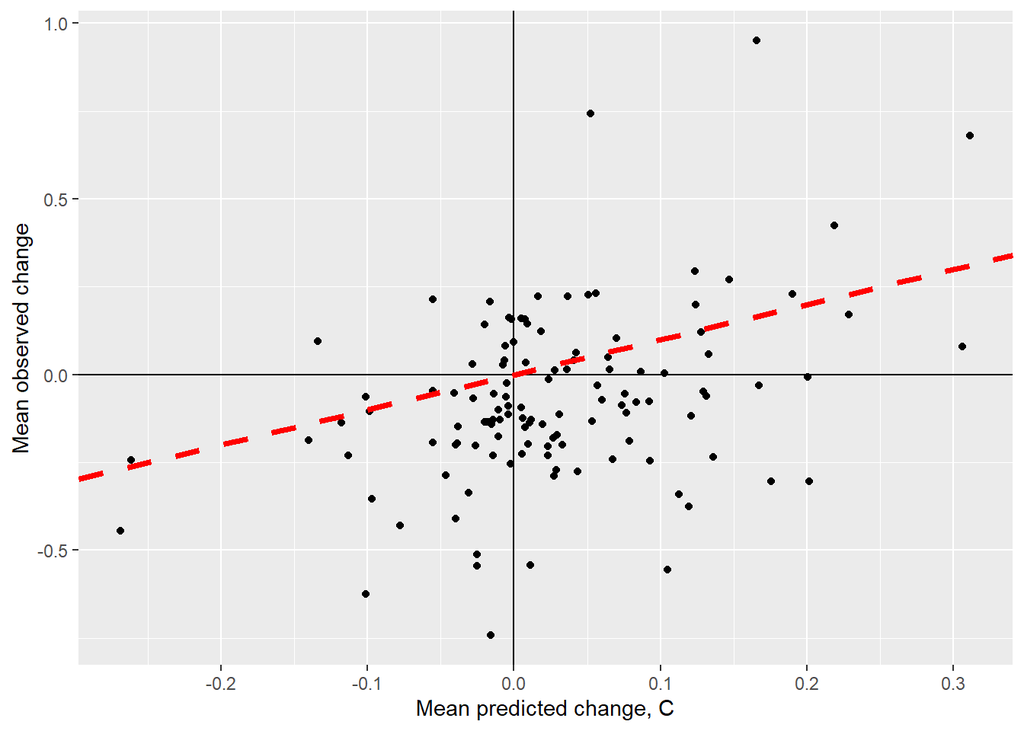

```r
ggplot(kat, aes(x=Ap2k, y=Ayk))+ geom_point()+
  geom_hline(yintercept = 0, color = "black")+
  geom_vline(xintercept = 0, color = "black")+
  xlab("Mean predicted change, C")+
  ylab("Mean observed change")+
  geom_abline(intercept = 0, slope = 1, color="red",linetype="dashed", size=1.5)
```

```r
#+ geom_text(aes(label=kat),hjust=0, vjust=0) +  geom_smooth()
```

Tyyli D.

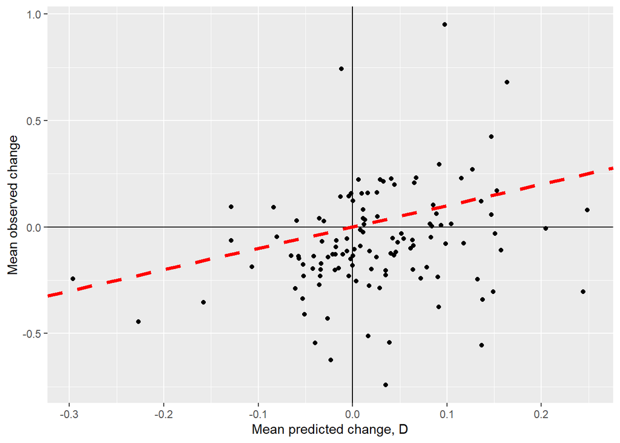

```r
ggplot(kat, aes(x=Ap1k, y=Ayk))+
  geom_point()+ geom_hline(yintercept = 0, color = "black")+
  geom_vline(xintercept = 0, color = "black")+
  xlab("Mean predicted change, D")+
  ylab("Mean observed change")+
  geom_abline(intercept = 0, slope = 1, color="red",linetype="dashed", size=1.5)
```

```r
  #+geom_text(aes(label=kat),hjust=0, vjust=0)+  geom_smooth() +xlim(-0.3,0.3)+ylim(-1,1)

write.csv(kat,"mean_observed_predicted_changes_abu.csv",row.names = F)
```

Kuvien skaalat eroavat taas hieman. Skaalan säätäminen tehtävä niin, että labeleistä pystyisi lukemaan edes jotain.

Hmm.. Jos näitä kuvia päädytään käyttämään, pitäisikö pohjansirkku tai peltopyy ottaa pois epätarkkoina? Ehkä ei? Koska havaintoja kyllä riittää mutta ne eivät vain satu samoille reiteille tai samoihin poolaus-ruutuihin.

#### tapahtuneen muutoksen ja ennustustarkkuuden suhde

Kuvaaja muutoksen suuruuden ja ennustustarkkuuden suhteesta:

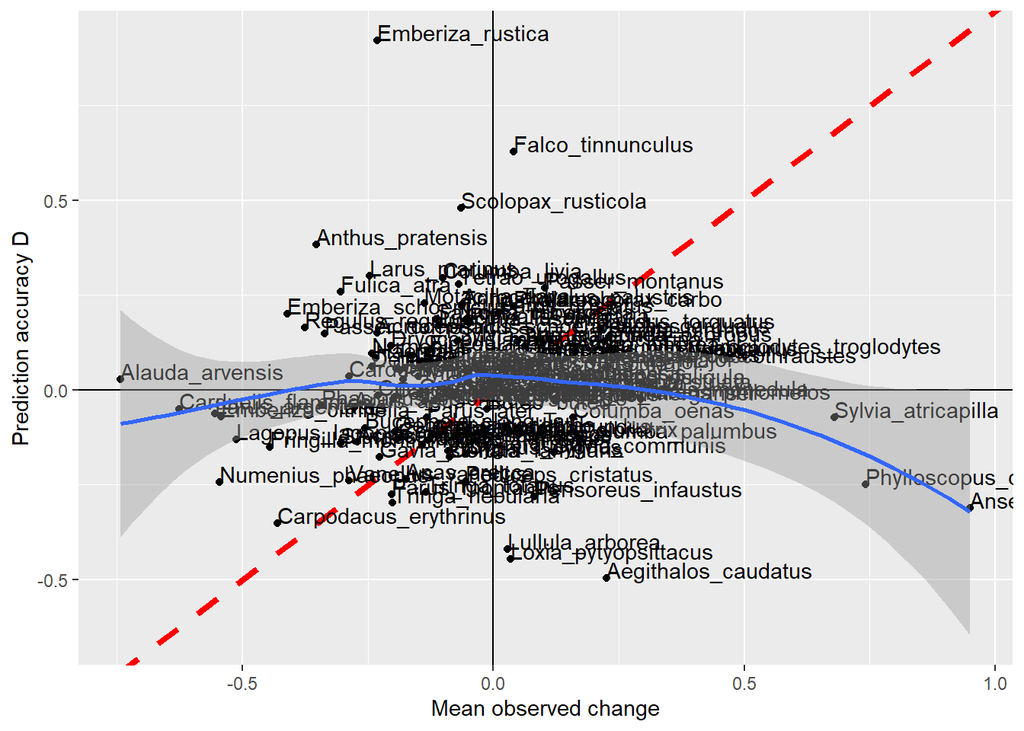

```r
kat2=cbind(kat,abu_results)

ggplot(kat2, aes(x=Ayk, y=abu_D))+
  geom_point()+ geom_hline(yintercept = 0, color = "black")+
  geom_vline(xintercept = 0, color = "black")+
  xlab("Mean observed change")+
  ylab("Prediction accuracy D")+
  geom_abline(intercept = 0, slope = 1, color="red",linetype="dashed", size=1.5)+
  geom_text(aes(label=kat),hjust=0, vjust=0)+  geom_smooth()
```

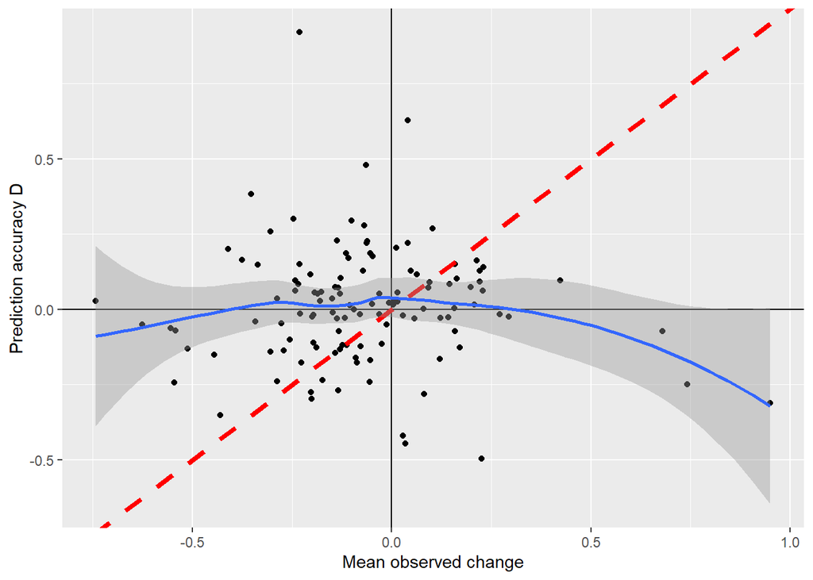

```r
ggplot(kat2, aes(x=Ayk, y=abu_D))+
  geom_point()+ geom_hline(yintercept = 0, color = "black")+
  geom_vline(xintercept = 0, color = "black")+
  xlab("Mean observed change")+
  ylab("Prediction accuracy D")+
  geom_abline(intercept = 0, slope = 1, color="red",linetype="dashed", size=1.5)+  geom_smooth()
```

Näistä kuvaajista on ehkäpä vaikea saada paljoa irti koska ennustustarkkuudet ovat niin huonoja yleisesti. Tässä myös muutos on laskettu koko alueelle. Eli vähentyminen toisaalla ja runsastuminen toisaalla saattavat kumota toisensa.

Lasken varianssin muutoksista jokaisella 264 linjalla, jota ennustustarkkuuden laskemiseen on käytetty.

```r
dat=as.data.frame(t(Ay))
dat$row_var=rowVars(as.matrix(dat),na.rm = TRUE)
dat=cbind(dat,abu_results)
```

Ja plottaan tulokset:

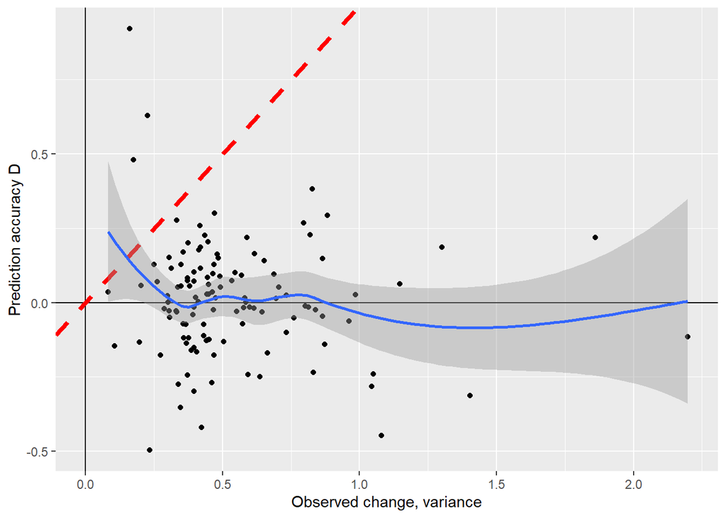

```r
ggplot(dat, aes(x=row_var, y=abu_D))+
  geom_point()+ geom_hline(yintercept = 0, color = "black")+
  geom_vline(xintercept = 0, color = "black")+
  xlab("Observed change, variance")+
  ylab("Prediction accuracy D")+
  geom_abline(intercept = 0, slope = 1, color="red",linetype="dashed", size=1.5)+  geom_smooth()
```

Tämäkään kuva ei varsinaisesti vihjaa siihen, että ennustustarkkuus riippuisi muutoksen määrästä.

HUOM! Näissä kuvissa on vielä mukana pohjansirkku ja peltopyy, vaikka myöhemmin poistan ne aineistosta. Siksi varmaankin alussa häntä todella korkealla.